# Prediction de la qualité de l'eau

###### CONTEXT : Agence de l’eau de Loire-Bretagne cherche à mettre en place une solution intelligente pour prédire la qualité de l’eau.

###### La problématique centrale de cette étude consiste à développer un modèle d'intelligence artificielle capable de prédire la qualité de l'eau en fonction de paramètres mesurables plus facilement et rapidement accessibles.

###### L'objectif est de créer un outil de prédiction qui peut anticiper les variations de la qualité de l'eau en utilisant des données historiques et en temps réel, permettant ainsi une intervention proactive pour maintenir

###### La qualité de l'eau à un niveau acceptable.

### Le Cahier des Charges :

#### - Exploiter l’historique des enregistrements de 2018, 2019 et 2020.

#### - Appliquer une étude EDA.

#### - Sélectionner les features importants (pas plus de 10 features, c’est une condition exigée par le client).

#### - Concaténer les trois bases de données (de 2018, 2019 et 2020).

#### - Reformuler la cible (target ou label) La cible de cette problématique est la colonne qui nommée « Classification ».

#### Ça sera bien de reformuler les targets de la façon suivante :

##### - C2S1 le reformuler comme Moderate

##### - C3S1 le reformuler comme Poor

##### - C4S2 le reformuler comme Bad

##### - C4S1 le reformuler comme Bad

##### - C3S2 le reformuler comme Poor

##### - C4S4 le reformuler comme Bad

##### - C4S3 le reformuler comme Bad

##### - C1S1 le reformuler comme Good

##### - C3S4 le reformuler comme Bad

##### - C3S3 le reformuler comme Poor

##### - C2S2 le reformuler comme Moderate (Supprimer les lignes pour les autres targets)

#### -Préparer les données pour la conception du modèle IA.

#### -Tester plusieurs modèles de classification et faire sélectionner le modèle le plus performant (faire changer les hyper paramètres de chaque modèle).

```python
import matplotlib.pyplot as plt
import seaborn as sns
import pandas as pd
import numpy as np
from sklearn.preprocessing import LabelEncoder
from sklearn.model_selection import train_test_split
from sklearn.neighbors import KNeighborsClassifier
from sklearn.model_selection import LeaveOneOut
from sklearn.model_selection import KFold, GridSearchCV
from sklearn.metrics import accuracy_score, precision_score, f1_score, recall_score, make_scorer
from sklearn.metrics import confusion_matrix
from sklearn.metrics import  ConfusionMatrixDisplay
from sklearn.tree import DecisionTreeClassifier
from sklearn.ensemble import RandomForestClassifier
from sklearn.svm import SVC
from sklearn.preprocessing import StandardScaler
from sklearn.ensemble import GradientBoostingClassifier
```

# Premiére étape

### initialisation de l'EDA

```python
df2018 = pd.read_csv('data-2018.csv')
df2019 = pd.read_csv('data-2019.csv')
df2020 = pd.read_csv('data-2020.csv')
```

```python
df2018.info()
```

```
<class 'pandas.core.frame.DataFrame'>
RangeIndex: 374 entries, 0 to 373
Data columns (total 26 columns):
 #   Column            Non-Null Count  Dtype
---  ------            --------------  -----
 0   sno               374 non-null    int64
 1   district          374 non-null    object
 2   mandal            374 non-null    object
 3   village           374 non-null    object
 4   lat_gis           374 non-null    float64
 5   long_gis          374 non-null    float64
 6   gwl               371 non-null    float64
 7   season            374 non-null    object
 8   pH                374 non-null    float64
 9   E.C               374 non-null    int64
```

[output cut: 18 more lines]

```python
df2019.info()
```

```
<class 'pandas.core.frame.DataFrame'>
RangeIndex: 364 entries, 0 to 363
Data columns (total 26 columns):
 #   Column            Non-Null Count  Dtype
---  ------            --------------  -----
 0   sno               364 non-null    int64
 1   district          364 non-null    object
 2   mandal            364 non-null    object
 3   village           364 non-null    object
 4   lat_gis           364 non-null    float64
 5   long_gis          364 non-null    float64
 6   gwl               359 non-null    float64
 7   season            364 non-null    object
 8   pH                364 non-null    float64
 9   EC                364 non-null    int64
```

[output cut: 18 more lines]

```python
df2020.info()
```

```
<class 'pandas.core.frame.DataFrame'>
RangeIndex: 368 entries, 0 to 367
Data columns (total 27 columns):
 #   Column            Non-Null Count  Dtype
---  ------            --------------  -----
 0   sno               368 non-null    int64
 1   district          368 non-null    object
 2   mandal            368 non-null    object
 3   village           368 non-null    object
 4   lat_gis           368 non-null    float64
 5   long_gis          368 non-null    float64
 6   gwl               365 non-null    float64
 7   season            368 non-null    object
 8   Unnamed: 8        0 non-null      float64
 9   pH                368 non-null    object
```

[output cut: 19 more lines]

### Nous pouvons remarquer que les trois dataset sont composés des mêmes colonnes

### A l'exception de :

- la colonne 'Unnamed: 8' de df2020 qui parait vide
- l'ensemble des colonnes de df2019 qui sont composées d'un caractére special en plus

### Nous remarquons que nous avons dans nos colonnes, trois types : int64 / float64 / object

### avant de faire concatainer les trois Dataset , nous allons les nettoyer un par un

```python
df2020.drop(['Unnamed: 8'], axis=1, inplace=True)
df2020.columns
```

```
Index(['sno', 'district', 'mandal', 'village', 'lat_gis', 'long_gis', 'gwl',
       'season', 'pH', 'E.C', 'TDS', 'CO3', 'HCO3', 'Cl', 'F', 'NO3 ', 'SO4',
       'Na', 'K', 'Ca', 'Mg', 'T.H', 'SAR', 'Classification', 'RSC  meq  / L',
       'Classification.1'],
      dtype='object')
```

```python
# obj_columns_df1 = df2018.select_dtypes(include=['object']).columns.difference(['Classification'])
# obj_columns_df2 = df2019.select_dtypes(include=['object']).columns.difference(['Classification'])
# obj_columns_df3 = df2020.select_dtypes(include=['object']).columns.difference(['Classification'])
# df2018 = df2018.drop(columns=obj_columns_df1)
# df2019 = df2019.drop(columns=obj_columns_df2)
# df2020 = df2020.drop(columns=obj_columns_df3)
```

```python
df2019 = df2019.rename(columns={'EC': 'E.C','CO_-2 ': 'CO3','HCO_ - ': 'HCO3','Cl -': 'Cl','F -': 'F','NO3- ': 'NO3 ','SO4-2': 'SO4', 'Na+': 'Na', 'K+': 'K', 'Ca+2': 'Ca', 'Mg+2': 'Mg'})
```

```python
master_df = pd.concat([df2018, df2019, df2020], ignore_index=True)
```

```python
master_df.shape
```

```
(1106, 26)
```

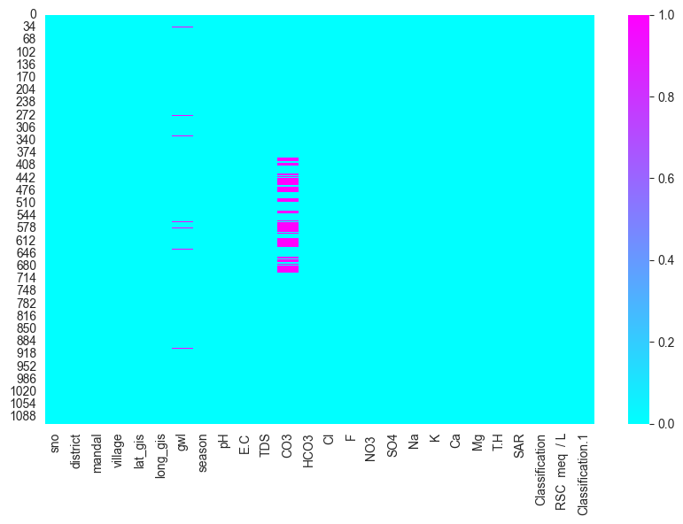

```python
plt.figure(figsize=(10,6))
heatmaps = sns.heatmap(master_df.isna(), cmap='cool')
plt.show()
```

```python
master_df.duplicated().sum()
```

```
0
```

```python
master_df['Classification'].replace( {"C3S1": "Poor",
"C3S2": "Poor",
"C3S3": "Poor",
"C2S2": "Moderate",
"C2S1": "Moderate",
"C4S2": "Bad",
"C4S1": "Bad",
"C4S4": "Bad",
"C4S3": "Bad",
"C3S4": "Bad",
"C1S1": "Good"
}, inplace=True  )
master_df['Classification'].unique()
```

```
array(['Moderate', 'Poor', 'Bad', 'Good', 'OG', 'O.G'], dtype=object)
```

```python
values_remove = ["OG", "O.G"]
master_df = master_df[~master_df['Classification'].isin(values_remove)]
```

```python
master_df['Classification'].value_counts()
```

```
Classification
Poor        714
Moderate    249
Bad         136
Good          3
Name: count, dtype: int64
```

```python
le = LabelEncoder()
master_df['Classification'] = le.fit_transform(master_df['Classification'])
```

```python
master_df['Classification'].unique()
```

```
array([2, 3, 0, 1])
```

```python
master_df['pH'] = master_df['pH'].replace('8..05', '8.05')
master_df['pH'] = master_df['pH'].astype(float)
```

```python
master_df.info()
```

```
<class 'pandas.core.frame.DataFrame'>
Index: 1102 entries, 0 to 1105
Data columns (total 26 columns):
 #   Column            Non-Null Count  Dtype
---  ------            --------------  -----
 0   sno               1102 non-null   int64
 1   district          1102 non-null   object
 2   mandal            1102 non-null   object
 3   village           1102 non-null   object
 4   lat_gis           1102 non-null   float64
 5   long_gis          1102 non-null   float64
 6   gwl               1091 non-null   float64
 7   season            1102 non-null   object
 8   pH                1102 non-null   float64
 9   E.C               1102 non-null   int64
```

[output cut: 18 more lines]

```python
clean_df = master_df.select_dtypes(exclude=['object'])
```

```python
clean_df.info()
```

```
<class 'pandas.core.frame.DataFrame'>
Index: 1102 entries, 0 to 1105
Data columns (total 21 columns):
 #   Column          Non-Null Count  Dtype
---  ------          --------------  -----
 0   sno             1102 non-null   int64
 1   lat_gis         1102 non-null   float64
 2   long_gis        1102 non-null   float64
 3   gwl             1091 non-null   float64
 4   pH              1102 non-null   float64
 5   E.C             1102 non-null   int64
 6   TDS             1102 non-null   float64
 7   CO3             942 non-null    float64
 8   HCO3            1102 non-null   float64
 9   Cl              1102 non-null   int64
 10  F               1102 non-null   float64
 11  NO3             1102 non-null   float64
 12  SO4             1102 non-null   float64
 13  Na              1102 non-null   float64
 14  K               1102 non-null   float64
 15  Ca              1102 non-null   float64
 16  Mg              1102 non-null   float64
 17  T.H             1102 non-null   float64
 18  SAR             1102 non-null   float64
 19  Classification  1102 non-null   int32
 20  RSC  meq  / L   1102 non-null   float64
dtypes: float64(17), int32(1), int64(3)
memory usage: 185.1 KB
```

```
                     sno   lat_gis  long_gis       gwl        pH       E.C  \
sno             1.000000 -0.165232 -0.206701  0.121915 -0.082699  0.057295
lat_gis        -0.165232  1.000000  0.111085 -0.078692 -0.075328 -0.287761
long_gis       -0.206701  0.111085  1.000000 -0.229305  0.174913 -0.071231
gwl             0.121915 -0.078692 -0.229305  1.000000 -0.106433 -0.027097
pH             -0.082699 -0.075328  0.174913 -0.106433  1.000000 -0.171667
E.C             0.057295 -0.287761 -0.071231 -0.027097 -0.171667  1.000000
TDS             0.057295 -0.287761 -0.071231 -0.027097 -0.171667  1.000000
CO3            -0.043429 -0.166406  0.047127 -0.028778  0.575872 -0.081422
HCO3            0.027162 -0.191084 -0.054354 -0.007314 -0.129018  0.588617
Cl              0.082204 -0.263844 -0.090951 -0.019211 -0.192334  0.932253
F               0.077148 -0.095197 -0.014669  0.067777  0.135987  0.077930
NO3            -0.014612 -0.191912  0.018474  0.000701 -0.095355  0.583265
SO4            -0.029660  0.161898  0.098371 -0.130906  0.048257  0.401736
Na             -0.004958 -0.218949  0.020796 -0.084504  0.098875  0.789708
K               0.021517  0.004531  0.091484 -0.062752  0.010456  0.288753
Ca              0.128651 -0.194785 -0.175257  0.047620 -0.446724  0.662850
Mg              0.013849 -0.175226 -0.024048 -0.017252 -0.108182  0.742316
T.H             0.087559 -0.225592 -0.122444  0.018648 -0.339303  0.854033
SAR            -0.044611 -0.165011  0.055443 -0.070500  0.255615  0.444875
Classification  0.006567  0.119392 -0.013318 -0.003031  0.031476 -0.515528
RSC  meq  / L  -0.081708  0.130069  0.105515 -0.025893  0.331980 -0.605860

                     TDS       CO3      HCO3        Cl  ...      NO3   \
sno             0.057295 -0.043429  0.027162  0.082204  ... -0.014612
lat_gis        -0.287761 -0.166406 -0.191084 -0.263844  ... -0.191912
long_gis       -0.071231  0.047127 -0.054354 -0.090951  ...  0.018474
gwl            -0.027097 -0.028778 -0.007314 -0.019211  ...  0.000701
pH             -0.171667  0.575872 -0.129018 -0.192334  ... -0.095355
E.C             1.000000 -0.081422  0.588617  0.932253  ...  0.583265
TDS             1.000000 -0.081422  0.588617  0.932253  ...  0.583265
CO3            -0.081422  1.000000 -0.045797 -0.116768  ... -0.090225
HCO3            0.588617 -0.045797  1.000000  0.339321  ...  0.164918
Cl              0.932253 -0.116768  0.339321  1.000000  ...  0.469236
F               0.077930  0.192394  0.359312 -0.061760  ... -0.061461
NO3             0.583265 -0.090225  0.164918  0.469236  ...  1.000000
SO4             0.401736 -0.045535  0.100541  0.347261  ...  0.134616
Na              0.789708  0.110631  0.608983  0.677993  ...  0.355236
K               0.288753 -0.017063  0.128309  0.230787  ...  0.333129
Ca              0.662850 -0.224344  0.260058  0.690378  ...  0.410784
```

[output cut: 38 more lines]

```
HCO3            0.500143       -0.166101       0.095717
Cl              0.309829       -0.516491      -0.737452
F               0.387040        0.074699       0.297046
NO3             0.129940       -0.388473      -0.517536
SO4             0.306788       -0.222173      -0.229601
Na              0.837976       -0.449197      -0.068350
K               0.158430       -0.188540      -0.085395
Ca             -0.092751       -0.295902      -0.760928
Mg              0.058889       -0.352239      -0.665622
T.H            -0.021554       -0.393487      -0.867889
SAR             1.000000       -0.279272       0.307978
Classification -0.279272        1.000000       0.330860
RSC  meq  / L   0.307978        0.330860       1.000000

[21 rows x 21 columns]
```

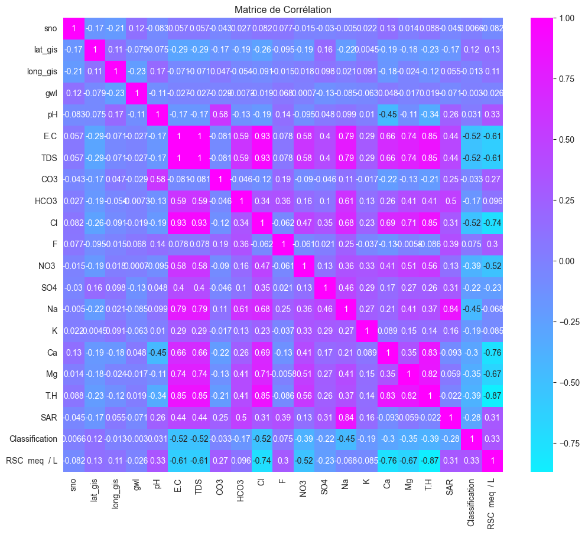

```python
correlation_matrix = clean_df.corr()
print(correlation_matrix)
plt.figure(figsize=(12, 10))
sns.heatmap(correlation_matrix, annot=True, cmap='cool', center=0)
plt.title("Matrice de Corrélation")
plt.show()
```

```python
correlations_with_target = correlation_matrix['Classification'].abs()

top_correlations = correlations_with_target.sort_values(ascending=False)

top_features = top_correlations.head(11).index

top_features_df = pd.DataFrame({'Top Features': top_features})

clean_df = master_df.loc[:, top_features]

print(top_features_df)
```

```
      Top Features
0   Classification
1               Cl
2              TDS
3              E.C
4               Na
5              T.H
6             NO3
7               Mg
8    RSC  meq  / L
9               Ca
10             SAR
```

```python
clean_df.info()
```

```
<class 'pandas.core.frame.DataFrame'>
Index: 1102 entries, 0 to 1105
Data columns (total 11 columns):
 #   Column          Non-Null Count  Dtype
---  ------          --------------  -----
 0   Classification  1102 non-null   int32
 1   Cl              1102 non-null   int64
 2   TDS             1102 non-null   float64
 3   E.C             1102 non-null   int64
 4   Na              1102 non-null   float64
 5   T.H             1102 non-null   float64
 6   NO3             1102 non-null   float64
 7   Mg              1102 non-null   float64
 8   RSC  meq  / L   1102 non-null   float64
 9   Ca              1102 non-null   float64
 10  SAR             1102 non-null   float64
dtypes: float64(8), int32(1), int64(2)
memory usage: 99.0 KB
```

```python
duplicated = clean_df[clean_df.duplicated(keep=False)]
duplicated
```

|  | Classification | Cl | TDS | E.C | Na | T.H | NO3 | Mg | RSC meq / L | Ca | SAR |
| --- | --- | --- | --- | --- | --- | --- | --- | --- | --- | --- | --- |
| 248 | 3 | 300 | 1137.92 | 1778 | 121.990758 | 579.917763 | 122.683300 | 48.620 | -5.080797 | 152.0 | 2.202500 |
| 257 | 3 | 300 | 1137.92 | 1778 | 121.990758 | 579.917763 | 122.683300 | 48.620 | -5.080797 | 152.0 | 2.202500 |
| 467 | 3 | 160 | 904.96 | 1414 | 96.000000 | 539.893092 | 73.078500 | 63.206 | -2.197862 | 112.0 | 1.796344 |
| 472 | 3 | 140 | 790.40 | 1235 | 70.500000 | 519.884868 | 68.649500 | 68.068 | -3.197697 | 96.0 | 1.344336 |
| 474 | 3 | 130 | 720.64 | 1126 | 55.000000 | 459.909539 | 26.574000 | 53.482 | -1.998191 | 96.0 | 1.115061 |
| 476 | 3 | 120 | 716.80 | 1120 | 118.500000 | 319.934211 | 13.419870 | 38.896 | 0.801316 | 64.0 | 2.880449 |
| 612 | 3 | 260 | 718.72 | 1123 | 120.000000 | 299.967105 | 150.586000 | 19.448 | -4.799342 | 88.0 | 3.012427 |
| 621 | 3 | 260 | 718.72 | 1123 | 120.000000 | 299.967105 | 150.586000 | 19.448 | -4.799342 | 88.0 | 3.012427 |
| 634 | 3 | 130 | 720.64 | 1126 | 55.000000 | 459.909539 | 26.574000 | 53.482 | -1.998191 | 96.0 | 1.115061 |
| 639 | 3 | 140 | 790.40 | 1235 | 70.500000 | 519.884868 | 68.649500 | 68.068 | -3.197697 | 96.0 | 1.344336 |
| 641 | 3 | 120 | 716.80 | 1120 | 118.500000 | 319.934211 | 13.419870 | 38.896 | 0.801316 | 64.0 | 2.880449 |
| 645 | 3 | 160 | 904.96 | 1414 | 96.000000 | 539.893092 | 73.078500 | 63.206 | -2.197862 | 112.0 | 1.796344 |
| 925 | 2 | 80 | 347.52 | 543 | 52.000000 | 199.950658 | 3.215454 | 29.172 | -0.399013 | 32.0 | 1.598873 |
| 941 | 3 | 40 | 602.88 | 942 | 45.750000 | 379.942434 | 34.280460 | 34.034 | 0.001151 | 96.0 | 1.020480 |
| 947 | 3 | 40 | 602.88 | 942 | 45.750000 | 379.942434 | 34.280460 | 34.034 | 0.001151 | 96.0 | 1.020480 |
| 949 | 2 | 80 | 347.52 | 543 | 52.000000 | 199.950658 | 3.215454 | 29.172 | -0.399013 | 32.0 | 1.598873 |

```python
clean_df = clean_df.drop_duplicates()
```

```python
clean_df.duplicated().sum()
```

```
0
```

```python
clean_df['Classification'].value_counts()
```

```
Classification
3    707
2    248
0    136
1      3
Name: count, dtype: int64
```

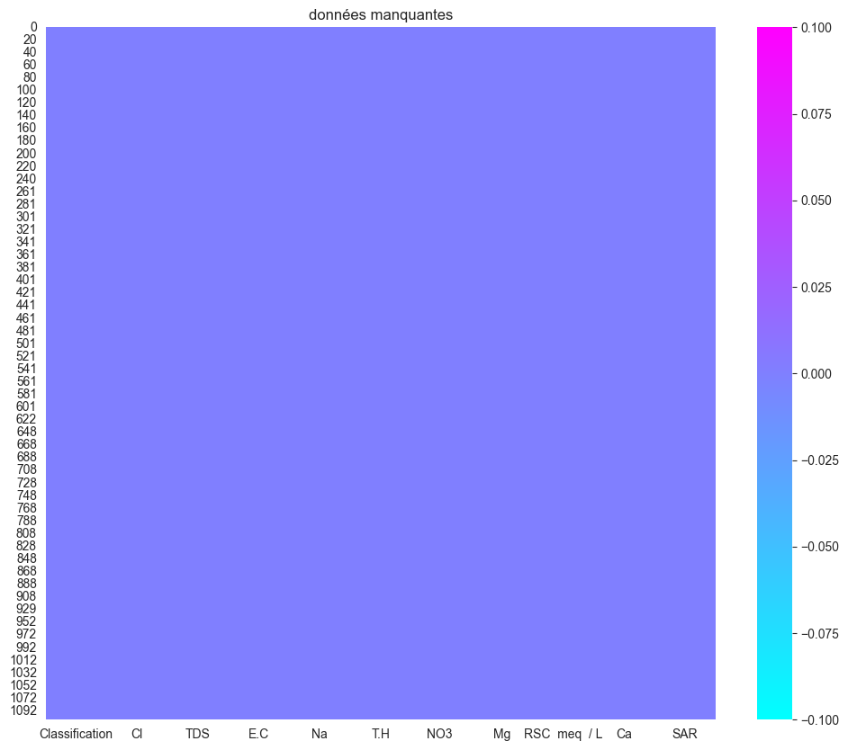

```python
plt.figure(figsize=(12, 10))
sns.heatmap(clean_df.isna(), cmap="cool")
plt.title("données manquantes")
plt.show()
```

```python
clean_df.isna().sum()
```

```
Classification    0
Cl                0
TDS               0
E.C               0
Na                0
T.H               0
NO3               0
Mg                0
RSC  meq  / L     0
Ca                0
SAR               0
dtype: int64
```

```python
clean_df['Classification'].value_counts()
```

```
Classification
3    707
2    248
0    136
1      3
Name: count, dtype: int64
```

```python
clean_df['Classification'] = clean_df['Classification']+1
```

```python
np.unique(clean_df['Classification'])
```

```
array([1, 2, 3, 4])
```

```python
# Q1 = clean_df.quantile(0.25)
# Q3 = clean_df.quantile(0.75)
# IQR = Q3 - Q1
# outlier_indices = ((clean_df < (Q1 - 1.5 * IQR)) | (clean_df > (Q3 + 1.5 * IQR))).any(axis=1)
# clean_df[outlier_indices] = np.nan
```

```python
def replace_outliers(series, threshold=1.5):
    if series.name != 'Classification':
        Q1 = series.quantile(0.25)
        Q3 = series.quantile(0.75)
        IQR = Q3 - Q1
        lower_bound = Q1 - threshold * IQR
        upper_bound = Q3 + threshold * IQR
        outliers_mask = (series < lower_bound) | (series > upper_bound)
        series[outliers_mask] = np.nan
    return series


df_cleaned = clean_df.apply(replace_outliers)
```

```python
df_cleaned.isna().sum()
```

```
Classification     0
Cl                48
TDS               46
E.C               46
Na                64
T.H               39
NO3               75
Mg                41
RSC  meq  / L     87
Ca                48
SAR               66
dtype: int64
```

```python
df_cleaned['Classification'].value_counts()
```

```
Classification
4    707
3    248
1    136
2      3
Name: count, dtype: int64
```

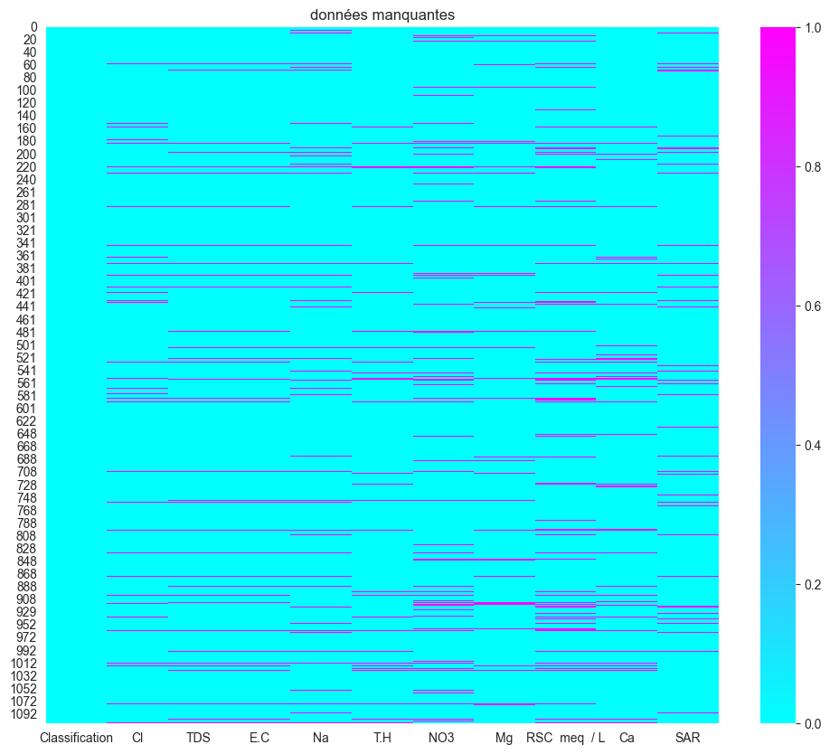

```python
plt.figure(figsize=(12, 10))
sns.heatmap(df_cleaned.isna(), cmap="cool")
plt.title("données manquantes")
plt.show()
```

```python
df_cleaned = clean_df.dropna()
df_cleaned.isnull().sum()
```

```
Classification    0
Cl                0
TDS               0
E.C               0
Na                0
T.H               0
NO3               0
Mg                0
RSC  meq  / L     0
Ca                0
SAR               0
dtype: int64
```

```python
df_cleaned.to_csv('verifDATA2.csv', index=False)
```

```python
X ,y = df_cleaned.drop('Classification', axis=1), df_cleaned['Classification']
kf = KFold(n_splits=5, shuffle=True, random_state=42)
print("Shape of X:", X.shape)
print("Shape of y:", y.shape)
```

[output not shown]

```
========================================
RandomForestClassifier
========================================
Best parameters: {'max_depth': None, 'min_samples_split': 5, 'n_estimators': 100}
========================================
mean accuracy: 0.9945
mean precision: 0.9946
mean recall: 0.9945
mean f1_score: 0.9936
========================================
Confusion Matrix:
[[ 21   0   0   2]
 [  0   3   0   0]
 [  0   0 246   0]
 [  0   0   0 633]]
========================================
```

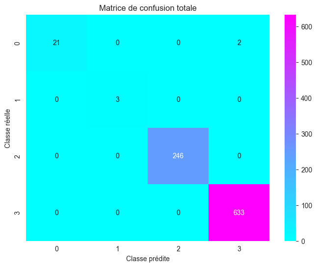

```python
param_grid = {
    'n_estimators': [100, 200],
    'max_depth': [None, 3],
    'min_samples_split': [2, 5]
}


clf = RandomForestClassifier()


scoring = {
    'accuracy': make_scorer(accuracy_score),
    'precision': make_scorer(precision_score, average='weighted', zero_division=1),
    'recall': make_scorer(recall_score, average='weighted'),
    'f1_score': make_scorer(f1_score, average='weighted')
}

grid_search = GridSearchCV(clf, param_grid, scoring=scoring, cv=kf, refit='accuracy')
grid_search.fit(X, y)
best_estimator = grid_search.best_estimator_
best_estimator.fit(X, y)
y_pred = best_estimator.predict(X)
confusion = confusion_matrix(y, y_pred)

print("="*40)
print(grid_search.best_estimator_.__class__.__name__)
print("="*40)
print("Best parameters:", grid_search.best_params_)
print("="*40)
for metric_name, metric_scorer in scoring.items():
    metric_value = grid_search.cv_results_[f"mean_test_{metric_name}"][grid_search.best_index_]
    print(f"mean {metric_name}: {metric_value:.4f}")
print("="*40)
print("Confusion Matrix:")
print(confusion)
print("="*40)

plt.figure(figsize=(8, 6))
sns.heatmap(confusion, annot=True, cmap='cool', fmt='d')
plt.title("Matrice de confusion totale")
plt.xlabel("Classe prédite")
plt.ylabel("Classe réelle")
plt.show()
```

```
========================================
DecisionTreeClassifier
========================================
Best parameters: {'criterion': 'gini', 'max_depth': None, 'min_samples_leaf': 4, 'min_samples_split': 2}
========================================
mean accuracy: 0.9934
mean precision: 0.9945
mean recall: 0.9934
mean f1_score: 0.9934
========================================
Confusion Matrix:
[[ 21   0   0   2]
 [  0   3   0   0]
 [  0   1 245   0]
 [  0   0   0 633]]
========================================
```

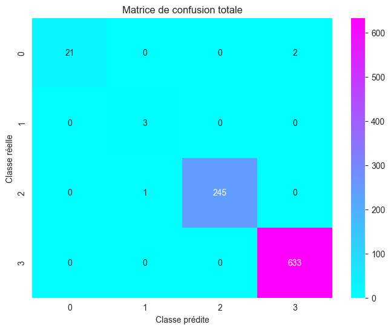

```python
param_grid = {
    'max_depth': [None, 3, 5, 10],
    'min_samples_split': [2, 5, 10],
    'min_samples_leaf': [1, 2, 4],
    'criterion': ['gini', 'entropy']
}

clf = DecisionTreeClassifier()

scoring = {
    'accuracy': make_scorer(accuracy_score),
    'precision': make_scorer(precision_score, average='weighted', zero_division=1),
    'recall': make_scorer(recall_score, average='weighted'),
    'f1_score': make_scorer(f1_score, average='weighted')
}

grid_search = GridSearchCV(clf, param_grid, scoring=scoring, cv=kf, refit='accuracy')
grid_search.fit(X, y)

best_estimator = grid_search.best_estimator_
best_estimator.fit(X, y)
y_pred = best_estimator.predict(X)
confusion = confusion_matrix(y, y_pred)

print("="*40)
print(grid_search.best_estimator_.__class__.__name__)
print("="*40)
print("Best parameters:", grid_search.best_params_)
print("="*40)
for metric_name, metric_scorer in scoring.items():
    metric_value = grid_search.cv_results_[f"mean_test_{metric_name}"][grid_search.best_index_]
    print(f"mean {metric_name}: {metric_value:.4f}")
print("="*40)
print("Confusion Matrix:")
print(confusion)
print("="*40)

plt.figure(figsize=(8, 6))
sns.heatmap(confusion, annot=True, cmap='cool', fmt='d')
plt.title("Matrice de confusion totale")
plt.xlabel("Classe prédite")
plt.ylabel("Classe réelle")
plt.show()
```

```
========================================
SVC
========================================
Best parameters: {'C': 10, 'gamma': 'scale', 'kernel': 'rbf'}
========================================
mean accuracy: 0.9856
mean precision: 0.9870
mean recall: 0.9856
mean f1_score: 0.9842
========================================
Confusion Matrix:
[[ 21   0   0   2]
 [  0   0   3   0]
 [  0   0 246   0]
 [  0   0   2 631]]
========================================
```

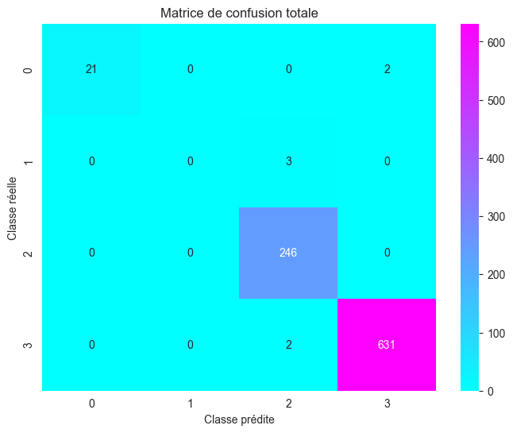

```python
param_grid = {
    'C': [1, 10],
    'kernel': ['linear', 'rbf'],
    'gamma': ['scale', 'auto']
}

clf = SVC()

scoring = {
    'accuracy': make_scorer(accuracy_score),
    'precision': make_scorer(precision_score, average='weighted', zero_division=1),
    'recall': make_scorer(recall_score, average='weighted'),
    'f1_score': make_scorer(f1_score, average='weighted')
}

grid_search = GridSearchCV(clf, param_grid, scoring=scoring, cv=kf, refit='accuracy')
grid_search.fit(X, y)

best_estimator = grid_search.best_estimator_
best_estimator.fit(X, y)
y_pred = best_estimator.predict(X)
confusion = confusion_matrix(y, y_pred)

print("="*40)
print(grid_search.best_estimator_.__class__.__name__)
print("="*40)
print("Best parameters:", grid_search.best_params_)
print("="*40)
for metric_name, metric_scorer in scoring.items():
    metric_value = grid_search.cv_results_[f"mean_test_{metric_name}"][grid_search.best_index_]
    print(f"mean {metric_name}: {metric_value:.4f}")
print("="*40)
print("Confusion Matrix:")
print(confusion)
print("="*40)

plt.figure(figsize=(8, 6))
sns.heatmap(confusion, annot=True, cmap='cool', fmt='d')
plt.title("Matrice de confusion totale")
plt.xlabel("Classe prédite")
plt.ylabel("Classe réelle")
plt.show()
```

```
========================================
GradientBoostingClassifier
========================================
Best parameters: {'learning_rate': 0.1, 'max_depth': 3, 'n_estimators': 50}
========================================
mean accuracy: 0.9912
mean precision: 0.9921
mean recall: 0.9912
mean f1_score: 0.9906
========================================
Confusion Matrix:
[[ 23   0   0   0]
 [  0   3   0   0]
 [  0   0 246   0]
 [  0   0   0 633]]
========================================
```

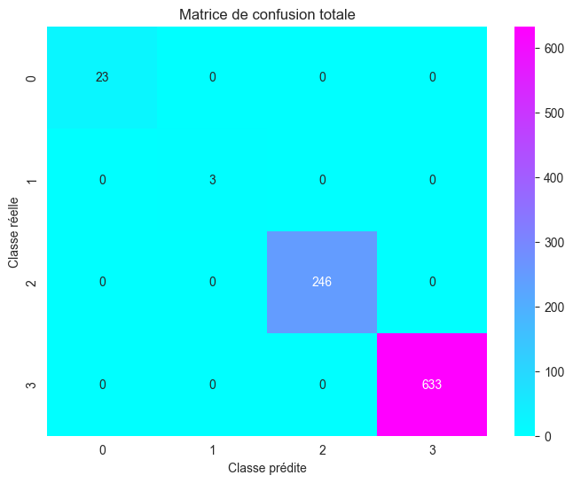

```python
param_grid = {
    'n_estimators': [50, 200],
    'learning_rate': [0.1, 0.2],
    'max_depth': [3, 5]
}

clf = GradientBoostingClassifier()

scoring = {
    'accuracy': make_scorer(accuracy_score),
    'precision': make_scorer(precision_score, average='weighted', zero_division=1),
    'recall': make_scorer(recall_score, average='weighted'),
    'f1_score': make_scorer(f1_score, average='weighted')
}

grid_search = GridSearchCV(clf, param_grid, scoring=scoring, cv=kf, refit='accuracy')
grid_search.fit(X, y)

best_estimator = grid_search.best_estimator_
best_estimator.fit(X, y)
y_pred = best_estimator.predict(X)
confusion = confusion_matrix(y, y_pred)

print("="*40)
print(grid_search.best_estimator_.__class__.__name__)
print("="*40)
print("Best parameters:", grid_search.best_params_)
print("="*40)
for metric_name, metric_scorer in scoring.items():
    metric_value = grid_search.cv_results_[f"mean_test_{metric_name}"][grid_search.best_index_]
    print(f"mean {metric_name}: {metric_value:.4f}")
print("="*40)
print("Confusion Matrix:")
print(confusion)
print("="*40)

plt.figure(figsize=(8, 6))
sns.heatmap(confusion, annot=True, cmap='cool', fmt='d')
plt.title("Matrice de confusion totale")
plt.xlabel("Classe prédite")
plt.ylabel("Classe réelle")
plt.show()
```

```
========================================
KNeighborsClassifier
========================================
Best parameters: {'n_neighbors': 3, 'p': 1, 'weights': 'uniform'}
========================================
mean accuracy: 0.9834
mean precision: 0.9848
mean recall: 0.9834
mean f1_score: 0.9822
========================================
Confusion Matrix:
[[ 21   0   0   2]
 [  0   3   0   0]
 [  0   0 246   0]
 [  1   0   3 629]]
========================================
```

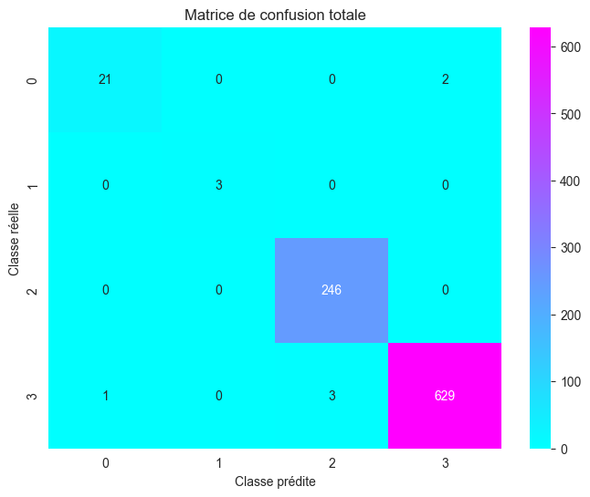

```python
param_grid = {
    'n_neighbors': [3, 7],
    'weights': ['uniform', 'distance'],
    'p': [1, 2]
}

clf = KNeighborsClassifier()

scoring = {
    'accuracy': make_scorer(accuracy_score),
    'precision': make_scorer(precision_score, average='weighted', zero_division=1),
    'recall': make_scorer(recall_score, average='weighted'),
    'f1_score': make_scorer(f1_score, average='weighted')
}

grid_search = GridSearchCV(clf, param_grid, scoring=scoring, cv=kf, refit='accuracy')
grid_search.fit(X, y)

best_estimator = grid_search.best_estimator_
best_estimator.fit(X, y)
y_pred = best_estimator.predict(X)
confusion = confusion_matrix(y, y_pred)

print("="*40)
print(grid_search.best_estimator_.__class__.__name__)
print("="*40)
print("Best parameters:", grid_search.best_params_)
print("="*40)
for metric_name, metric_scorer in scoring.items():
    metric_value = grid_search.cv_results_[f"mean_test_{metric_name}"][grid_search.best_index_]
    print(f"mean {metric_name}: {metric_value:.4f}")
print("="*40)
print("Confusion Matrix:")
print(confusion)
print("="*40)

plt.figure(figsize=(8, 6))
sns.heatmap(confusion, annot=True, cmap='cool', fmt='d')
plt.title("Matrice de confusion totale")
plt.xlabel("Classe prédite")
plt.ylabel("Classe réelle")
plt.show()
```